# User Guide

Søren Helweg Dam

Last updated: 2023.03.17

# 1 Introduction

Welcome to the User Guide for `pariedGSEA`! `pariedGSEA` is an R package that allows you to run a paired differential gene expression and splicing analysis. Providing a count matrix, `pariedGSEA` combines the results of `DESeq2` and `DEXSeq`, aggregates the p-values to gene level and allows you to run a subsequent gene set over-representation analysis using its implementation of the `fgsea::fora` function.

This manual will guide you through how to use the main functions of pairedGSEA.

`pariedGSEA` assumes you have already preprocessed and aligned your sequencing reads to transcript level. Before starting, you should therefore have a counts matrix and a metadata file. This data may also be in the format of a SummarizedExperiment or DESeqDataSet. Please ensure that the rownames have the format: `gene:transcript`.

The metadata should, as a minimum, contain the `sample IDs` corresponding to the column names of the count matrix, a `group` column containing information on which samples corresponds to the baseline (controls) and the case (condition). Bear in mind, the column names can be as you wish, but the names must be provided in the `sample_col` and `group_col` parameters, respectively.

To see an example of what such data could look like, please see `?pairedGSEA::example_se`.

# 2 Installation

To install this package, start R (version “4.2”) and enter:

```r
# Install Bioconductor packages with:
# devtools::install_bioc(c("DESeq2", "DEXSeq", "fgsea", "SummarizedExperiment",
# "S4Vectors", "sva", "BiocParallel"))

# Install pairedGSEA
devtools::install_github("shdam/pairedGSEA", build_vignettes = TRUE)
```

# 3 Paired differential expression and splicing

## 3.1 Preparing the experiment parameters

Running a paired Differential Gene Expression (DGE) and Differential Gene Splicing (DGS) analysis is the first step in the `pairedGSEA` workflow.

But before running the `paired_diff` function, we recommend storing the experiment parameters in a set of variables at the top of your script for future reference and easy access:

```r
library("pairedGSEA")

# Defining plotting theme
ggplot2::theme_set(ggplot2::theme_classic(base_size = 20))

## Load data
# In this vignette we will use the included example Summarized Experiment.
# See ?example_se for more information about the data.
data("example_se")

if(FALSE){ # Examples of other data imports
    # Example of count matrix
    tx_count <- read.csv("path/to/counts.csv") # Or other load function
    md_file <- "path/to/metadata.xlsx" # Can also be a .csv file or a data.frame

    # Example of locally stored DESeqDataSet
    dds <- readRDS("path/to/dds.RDS")

    # Example of locally stored SummarizedExperiment
    se <- readRDS("path/to/se.RDS")
}

## Experiment parameters
group_col <- "group_nr" # Column with the groups you would like to compare
sample_col <- "id" # Name of column that specifies the sample id of each sample.
# This is used to ensure the metadata and count data contains the same samples
# and to arrange the data according to the metadata
# (important for underlying tools)
baseline <- 1 # Name of baseline group
case <- 2 # Name of case group
experiment_title <- "TGFb treatment for 12h" # Name of your experiment. This is
# used in the file names that are stored if store_results is TRUE (recommended)
```

## 3.2 Check your metadata

```r
# Check if parameters above fit with metadaata
SummarizedExperiment::colData(example_se)
```

```
#> DataFrame with 6 rows and 5 columns
#>                  study          id                 source final_description
#>            <character> <character>            <character>       <character>
#> GSM1499784    GSE61220  GSM1499784 small airway epithel..       Epi,Control
#> GSM1499785    GSE61220  GSM1499785 small airway epithel..       Epi,Control
#> GSM1499786    GSE61220  GSM1499786 small airway epithel..       Epi,Control
#> GSM1499790    GSE61220  GSM1499790 small airway epithel..      Epi,TNF,12hr
#> GSM1499791    GSE61220  GSM1499791 small airway epithel..      Epi,TNF,12hr
#> GSM1499792    GSE61220  GSM1499792 small airway epithel..      Epi,TNF,12hr
#>            group_nr
#>            <factor>
#> GSM1499784        1
#> GSM1499785        1
#> GSM1499786        1
#> GSM1499790        2
#> GSM1499791        2
#> GSM1499792        2
```

```r
# Check that all data samples are in the metadata
all(colnames(example_se) %in%
        SummarizedExperiment::colData(example_se)[[sample_col]])
```

```
#> [1] TRUE
```

## 3.3 Running the analysis

The paired DGE/DGS analysis is run with `paired_diff()`. `paired_diff()` is essentially a wrapper function around `DESeq2::DESeq` (Love, Huber, and Anders 2014) and `DEXSeq::DEXSeq` (Anders, Reyes, and Huber 2012), the latter takes in the ballpark of 20-30 minutes to run depending on the size of the data and computational resources. Please visit their individual vignettes for further information.

```r
set.seed(500) # For reproducible results

diff_results <- paired_diff(
    object = example_se,
    metadata = NULL, # Use with count matrix or if you want to change it in
    # the input object
    group_col = group_col,
    sample_col = sample_col,
    baseline = baseline,
    case = case,
    experiment_title = experiment_title,
    store_results = FALSE # Set to TRUE (recommended)  if you want
    # to store intermediate results, such as the results on transcript level
    )
```

```
#> Running TGFb treatment for 12h
#> Preparing metadata
#> Warning in pre_filter(dds, prefilter):
#> Removing 0 rows with a summed count lower than 10
#> Removing 108 rows with counts in less than 2 samples.
#> Running SVA
#> No significant surrogate variables
#>
#> Found 0 surrogate variables
#> Running DESeq2
#> Extracting results
#> Initiating DEXSeq
#> Creating DEXSeqDataSet
#> Warning in DESeqDataSet(rse, design, ignoreRank = TRUE): some variables in
#> design formula are characters, converting to factors
#>
#> Running DEXSeq -- This might take a while
#> TGFb treatment for 12h is analysed.
#> Aggregating p values
#> Done.
```

```r
diff_results
```

```
#> # A tibble: 942 × 7
#>    gene            lfc_expression pvalue_expre…¹ padj_…² lfc_s…³ pvalu…⁴ padj_…⁵
#>    <chr>                    <dbl>          <dbl>   <dbl>   <dbl>   <dbl>   <dbl>
#>  1 ENSG00000000419        0.0420     0.772       8.46e-1  0.262  2.75e-1 5.12e-1
#>  2 ENSG00000001167       -0.391      0.000000528 3.23e-6 -0.0500 6.83e-1 8.58e-1
#>  3 ENSG00000003402        0.201      0.00000472  2.49e-5  0.338  2.84e-6 3.90e-5
#>  4 ENSG00000005007        0.101      0.0229      5.16e-2  0.484  7.98e-7 1.28e-5
#>  5 ENSG00000005020       -0.301      0.0197      4.49e-2  0.0989 6.02e-1 8.03e-1
#>  6 ENSG00000005810        0.138      0.0405      8.38e-2 -0.524  1.63e-1 3.56e-1
#>  7 ENSG00000005812        0.312      0.0000986   4.19e-4  0.403  3.88e-1 6.41e-1
#>  8 ENSG00000005893       -0.00949    0.751       8.29e-1  0.466  9.51e-1 9.96e-1
#>  9 ENSG00000006607        0.0460     0.0171      3.99e-2  0.334  4.47e-6 5.52e-5
#> 10 ENSG00000007174        0.461      0.339       4.68e-1  0.129  6.91e-1 8.67e-1
#> # … with 932 more rows, and abbreviated variable names ¹pvalue_expression,
#> #   ²padj_expression, ³lfc_splicing, ⁴pvalue_splicing, ⁵padj_splicing
```

After running the analyses, `paired_diff` will aggregate the p-values to gene level using lancaster aggregation (Lancaster 1961) and calculate the FDR-adjusted p-values (see `?paired:::aggregate_pvalue` for more information). For the DGE transcripts, the log2 fold changes will be aggregated using a weighted mean, whereas the DGS log2 fold changes will be assigned to the log2 fold change of the transcript with the lowest p-value. Use the latter with a grain of salt.

From here, feel free to analyse the gene-level results using your preferred method. If you set `store_results = TRUE`, you could extract the transcript level results found in the `results` folder under the names “*_expression_results.RDS” and “*_splicing_results.RDS” for the DGE and DGS analysis, respectively (The * corresponds to the provided experiment title).

## 3.4 Additional parameters

There are a range of other parameters you can play with to tailor-make the experience. Here, the default settings are showed. See `?pairedGSEA::paired_diff` for further details.

```r
covariates = NULL,
run_sva = TRUE,
prefilter = 10,
fit_type = "local",
test = "LRT",
quiet = FALSE,
parallel = TRUE,
BPPARAM = BiocParallel::bpparam(),
...
```

To highlight some examples of use:

1. You can use additional columns in your metadata as covariates in the model matrix by setting `covariates` to a character vector of the specific names. This will be used in SVA, DGE, and DGS.
2. The test should be kept at default settings, but advanced users may use the “wald” test instead, if they wish.
3. The `...` parameters will be fed to `DESeq2::DESeq`, see their manual for options.
4. If you want a stricter, more loose, or more advanced pre-filtering (generally not necessary, as DESeq2 and DEXSeq performs their own pre-filtering), you can set the parameter to a different value or NULL and use your own pre-filtering method directly on the counts matrix.

# 4 Over-Representation Analysis

`pairedGSEA` comes with a wrapper function for `fgsea::fora`. If you wish, feel free to use that directly or any other gene set analysis method - investigate the `diff_results` object before use to see what information it contains.

The inbuilt wrapper also computes the relative risk for each gene set and an enrichment score (`log2(relative_risk + 0.06)`, the pseudo count is for plotting purposes).

### 4.0.1 Running the inbuilt ORA function

Before you get going, you will need a list of gene sets (aka. pathways) according to the species you are working with and the category of gene sets of interest. For this purpose, feel free to use the internal `msigdbr` wrapper function in `pairedGSEA`: `pairedGSEA::prepare_msigdb`. If you do, see `?pairedGSEA::prepare_msigdb` for further details.

The inbuilt ORA function is called `paired_ora` and is run as follows

```r
# Define gene sets in your preferred way
gene_sets <- pairedGSEA::prepare_msigdb(
    species = "Homo sapiens",
    category = "C5",
    gene_id_type = "ensembl_gene"
    )

ora <- paired_ora(
    paired_diff_result = diff_results,
    gene_sets = gene_sets,
    experiment_title = NULL # experiment_title - if not NULL,
    # the results will be stored in an RDS object in the 'results' folder
    )
```

```
#> Identifying differentially expressed genes
#> Running over-representation analysis
#> Joining result
```

```r
ora
```

```
#> # A tibble: 555 × 18
#>    pathway       pval_…¹ padj_…² overl…³ size_…⁴ overl…⁵ size_…⁶ size_…⁷ relat…⁸
#>    <chr>           <dbl>   <dbl>   <int>   <int> <list>    <int>   <int>   <dbl>
#>  1 HP_ABNORMAL_…   0.993   0.995      10      38 <chr>       414     942   0.599
#>  2 GOBP_MICROTU…   0.925   0.945       8      25 <chr>       414     942   0.728
#>  3 GOMF_TRANSCR…   0.965   0.974      28      80 <chr>       414     942   0.796
#>  4 HP_ABNORMALI…   0.824   0.858      10      27 <chr>       414     942   0.843
#>  5 HP_ABNORMALI…   0.779   0.825      10      26 <chr>       414     942   0.875
#>  6 HP_ABNORMALI…   0.757   0.813      18      45 <chr>       414     942   0.910
#>  7 GOMF_SEQUENC…   0.722   0.790      34      82 <chr>       414     942   0.943
#>  8 GOBP_REGULAT…   0.637   0.738      14      33 <chr>       414     942   0.965
#>  9 HP_ABNORMAL_…   0.584   0.708      20      46 <chr>       414     942   0.989
#> 10 GOBP_MULTICE…   0.578   0.704      14      32 <chr>       414     942   0.995
#> # … with 545 more rows, 9 more variables: enrichment_score_expression <dbl>,
#> #   pval_splicing <dbl>, padj_splicing <dbl>, overlap_splicing <int>,
#> #   overlapGenes_splicing <list>, size_genes_splicing <int>,
#> #   relative_risk_splicing <dbl>, enrichment_score_splicing <dbl>,
#> #   enrichment_score_shift <dbl>, and abbreviated variable names
#> #   ¹pval_expression, ²padj_expression, ³overlap_expression, ⁴size_geneset,
#> #   ⁵overlapGenes_expression, ⁶size_genes_expression, ⁷size_universe, …
```

## 4.1 Additional parameters

```r
cutoff = 0.05,
min_size = 25,
quiet = FALSE
```

Please investigate the returned object to see the column names and what they contain.

# 5 Analysing ORA results

There are many options for investigating your ORA results. `pairedGSEA` comes with an inbuilt scatter plot function that plots the enrichment score of DGE against those of DGS.

The function allows you to interactively look at the placement of the significant pathways using `plotly`. You can color specific points based on a regular expression for gene sets of interest.

## 5.1 Scatter plot of enrichment scores

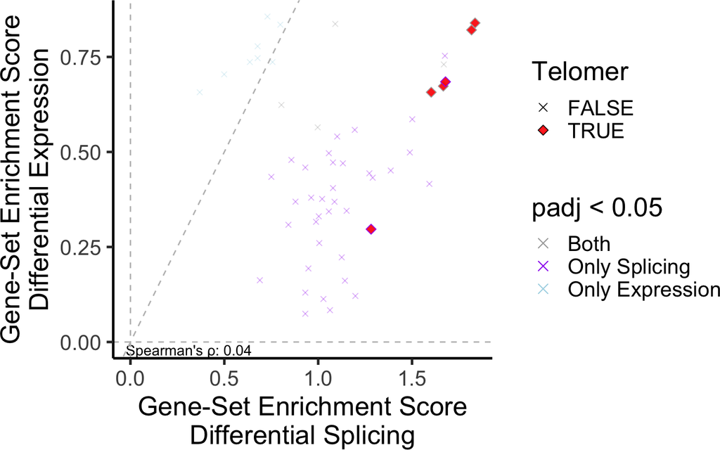

```r
# Scatter plot function with default settings
plot_ora(
    ora,
    plotly = FALSE,
    pattern = "Telomer", # Identify all gene sets about telomeres
    cutoff = 0.05, # Only include significant gene sets
    lines = TRUE # Guide lines
    )
```

As mentioned, this function can be utilized in a few different ways. The default settings will plot the enrichment scores of each analysis and draw dashed lines for the `y = x` line, `y = 0`, and `x = 0`. Remove those by setting `lines = FALSE`.

Make the plot interactive with `plotly = TRUE`.

Highlight gene sets containing a specific regex pattern by setting `pattern` to the regex pattern of interest.

# References

Anders, Simon, Alejandro Reyes, and Wolfgang Huber. 2012. “Detecting Differential Usage of Exons from RNA-Seq Data.” *Genome Research* 22 (10): 2008–17. https://doi.org/10.1101/gr.133744.111.

Lancaster, H. O. 1961. “THE COMBINATION OF PROBABILITIES: AN APPLICATION OF ORTHONORMAL FUNCTIONS.” *Australian Journal of Statistics* 3 (1): 20–33. https://doi.org/https://doi.org/10.1111/j.1467-842X.1961.tb00058.x.

Love, Michael I., Wolfgang Huber, and Simon Anders. 2014. “Moderated Estimation of Fold Change and Dispersion for RNA-Seq Data with DESeq2.” *Genome Biology* 15 (12): 550. https://doi.org/10.1186/s13059-014-0550-8.